# DACSS603Final

Author

Theresa Szczepanski

Published

October 22, 2023

```r
source('dependencies.R')
knitr::opts_chunk$set(echo = TRUE, warning=FALSE, message=FALSE)
#install.packages("stargazer")
library(stargazer)
```

# Research Questions

The Massachusetts Education Reform Act in 1993 was passed in the context of a national movement toward education reform throughout the United States. As early as 1989 there were calls to establish national curriculum standards as a way to improve student college and career readiness skills and close poverty gaps (Greer 2018). Massachusetts Comprehensive Assessment System (MCAS) tests were introduced as part of the Massachusetts Education Reform Act.

The MCAS tests are a significant tool for educational equity. Scores on the Grade 10 Math MCAS test “predict longer-term educational attainments and labor market success, above and beyond typical markers of student advantage” and differences among students are largely and “sometimes completely accounted for” by differences in 10th grade MCAS scores and educational attainments. (Papy 2020).

With the introduction of the new Common Core standards and accountability testing came the demand for aligned curricular materials and teaching practices. Research indicates that the choice of instructional materials can have an impact “as large as or larger than the impact of teacher quality” (Chingos 2012). Massachusetts, along with Arkansas, Delaware, Kentucky, Louisiana, Maryland, Mississippi, Nebraska, New Mexico, Ohio, Rhode Island, Tennessee, and Texas belongs to the Council of Chief State School Officers’ (CCSO), [High Quality Instructional Materials and Professional Development network](https://learning.ccsso.org/high-quality-instructional-materials) which aims to close the “opportunity gap” among students by ensuring that every teacher has access to high-quality, standards aligned instructional materials and receives relevant professional development to support their use of these materials (Chief State School Officers 2021).

All Massachusetts Public School students must complete a High School science MCAS exam providing a wealth of standardized data on students’ discipline specific skill development. All schools receive annual summary reports on student performance. Significant work has been done using the MCAS achievement data and the Student Opportunity Act to identify achievement gaps and address funding inequities across the Commonwealth (Papy 2020). With funding gaps outlined in the late 1990’s closing, one could consider how the MCAS data could be leveraged to support the state’s current high quality instructional materials initiatives. The state compiles school’s performance disaggregated by each MCAS question item (DESE 2022).

Using the curricular information provided in state wide Next Generation MCAS High School Introductory Physics Item reports together with school-level student performance data, we hope to address the following broad questions:

- Is there a relationship between differences in a school’s performance across Science Practice Categories and a school’s overall achievement on the Introductory Physics exam?
- How can trends in a school’s performance be used to provide schools with guidance on discipline-specific curricular areas to target to improve student achievement?

In this report, I will analyze the High School Introductory Physics Next Generation [Massachusetts Comprehensive Assessment System (MCAS)](https://www.doe.mass.edu/mcas/default.html) tests results for Massachusetts public schools.

Data for the study were drawn from DESE’s Next Generation MCAS Test [Achievement Results statewide report](https://profiles.doe.mass.edu/statereport/mcas.aspx), [Item Analysis statewide report](https://profiles.doe.mass.edu/statereport/nextgenmcas_item.aspx), and the [MCAS digital item library](https://mcas.digitalitemlibrary.com/home?subject=Science&grades=Physics&view=ALL). The Next Generation High School Introductory Physics MCAS assessment consists of 42 multiple choice and constructed response items that assess students on Physical Science standards from the [2016 STE Massachusetts Curriculum Framework](https://www.doe.mass.edu/frameworks/scitech/2016-04.pdf) in the content `Reporting Categories` of Motions and Forces, `MF`, Energy, `EN`, and Waves, `WA`. Each item is associated with a specific content standard from the Massachusetts Curriculum Framework as well as an underlying science `Practice Category` of Evidence Reasoning and Modeling, `ERM`, Mathematics and Data, `MD`, or Investigations and Questioning, `IQ`. The State Item Report provides the percentage of points earned by students in a school for each item as well as the percentage of points earned by all students in the state for each item.

- *School Characteristics*: This includes the name of the school and the size of the school, `School Size`, as determined by the number of students that completed the MCAS exam.
- *Discipline-Specifc Performance Metrics*: This includes the percentage of points earned by students at a school for items each content `Reporting Category`, `MF%`, `EN%`, `WA%` and science `Practice Category` `ERM%`, `MD%`, `IQ%`, the difference between a school’s percentage of points earned compared to the percentage of points earned by all students in the state (`MFDiff`, `ENDiff`, etc…), and the variability in a school’s performance relative to the state by category as measured by the standard deviation of the school’s `Diff` across categories (`SD MF Diff`, `SD EN Diff`, etc…).
- *Aggregate Performance Level metrics*: This includes a school’s percentage of students at each of the four `Performance Levels`, (`E%`: Exceeding Expectations, `M%`: Meeting Expectations, `PM%`: Partially Meeting Expectations, and `NM%`: Not Meeting Expectations), the difference between these percentages and the percentage of students in Massachusetts at each performance level (`EDiff`, `MDiff`, `PMDiff`, `NMDiff`), and an ordinal classification of school’s, `EM Perf Stat` based on the percentage of students that were classified as Exceeding or Meeting expectations on the exam (`HighEM`, `HighM`, `Mid`, `Mid-Low`, `Low`).

See the `HSPhy_NextGenMCASDF` data frame summary and **codebook** for further details about all variables.

# Hypothesis

- A school’s percentage of students classified as `Exceeding` expectations on the Introductory Physics MCAS is negatively associated with a school’s variance in performance relative to students in the state on `Mathematics and Data` items, `SD MD Diff`.
- A school’s summary performance on items in a given content `Reporting Category` as measured by `MF%`, `EN%`, and `WA%`, is positively associated with the `Reporting Category's` weight within the exam.

# Descriptive Statistics

```r
#HSPhy_NextGen_SchoolSum
HSPhy_NextGen_SchoolSum<-HSPhy_NextGen_SchoolSum%>%
  ungroup()

#HSPhy_NextGen_SchoolSum
# HSPhy_NextGen_PerfDF
# HSPhy_NextGen_SchoolIT301DF

HSPhy_2023_SchoolSizeDF<-read_excel("data/2023_Physics_NextGenMCASItem.xlsx", skip = 1)%>%
  select(`School Name`, `School Code`, `Tested`)%>%
  mutate(`Tested` = as.integer(`Tested`))%>%
  select(`School Name`, `School Code`, `Tested`)

HSPhy_2022_SchoolSizeDF<-read_excel("data/2022_Physics_NextGenMCASItem.xlsx", skip = 1)%>%
  select(`School Name`, `School Code`, `Tested`)%>%
  mutate(`Tested` = as.integer(`Tested`))%>%
  select(`School Name`, `School Code`, `Tested`)


HSPhy_SchoolSize <- rbind(HSPhy_2023_SchoolSizeDF, HSPhy_2022_SchoolSizeDF)%>%
  mutate(count = 1)%>%
  group_by(`School Name`, `School Code`)%>%
  summarise(count = sum(count),
            `Tested` = sum(`Tested`))%>%
  mutate(`Tested Count` = round(`Tested`/count))%>%
  ungroup()
#HSPhy_SchoolSize
quantile <- quantile(HSPhy_SchoolSize$`Tested Count`)
HSPhy_Size<-HSPhy_SchoolSize%>%
  mutate(`School Size` = case_when(
    `Tested Count` <= quantile[2] ~ "Small",
    `Tested Count` > quantile[2] &
      `Tested Count` <= quantile[3] ~ "Low-Mid",
    `Tested Count` > quantile[3] &
      `Tested Count` <= quantile[4] ~ "Upper-Mid",
    `Tested Count` > quantile[4] &
      `Tested Count` <= quantile[5] ~ "Large",
  ))%>%
  mutate(`School Size` = recode_factor(`School Size`,
                                            "Small" = "Small",
                                            "Low-Mid" = "Low-Mid",
                                            "Upper-Mid" = "Upper-Mid",
                                            "Large" = "Large",
                                            .ordered = TRUE))%>%
  select(`School Name`, `School Code`, `School Size`)


#HSPhy_Size

HSPhy_NextGen_SchoolSum<-HSPhy_NextGen_SchoolSum%>%
  left_join(HSPhy_Size, by = c("School Name" = "School Name", "School Code" = "School Code"))%>%
  mutate(`EMDiff` = `EDiff` + `MDiff`)%>%
  mutate(`EM Perf Stat` = case_when(
    `EDiff` > 0 & `EDiff` + `MDiff` > 0 ~ "HighEM",
    `EDiff` <= 0 & `EDiff` + `MDiff` > 0 ~ "HighM",
    #`EMDiff` > quantile(HSPhy_NextGen_SchoolSum$`EMDiff`)[3] &
      `EMDiff` <= 0  & `EMDiff` > -14 ~ "Mid",
    `EMDiff` <= -14 & `EMDiff` >= -33  ~ "Mid-Low",
    `EMDiff` < -33  ~ "Low"

  ))%>%
  mutate(`EM Perf Stat` = recode_factor(`EM Perf Stat`,
                                 "HighEM" = "HighEM",
                                 "HighM" = "HighM",
                                 "Mid" = "Mid",
                                 "Mid-Low" = "Mid-Low",
                                 "Low" = "Low",
                                 .ordered = TRUE))
HSPhy_NextGen_SchoolSum
```

| Subject | School Name | School Code | EN% | MF% | WA% | EN Diff SD | MF Diff SD | WA Diff SD | IQ% | MD% | ERM% | None% | IQ Diff SD | MD Diff SD | ERM Diff SD | None Diff SD | Tested Students | E% | M% | PM% | NM% | E%State | M%State | PM%State | NM%State | EDiff | MDiff | PMDiff | NMDiff | … |
| --- | --- | --- | --- | --- | --- | --- | --- | --- | --- | --- | --- | --- | --- | --- | --- | --- | --- | --- | --- | --- | --- | --- | --- | --- | --- | --- | --- | --- | --- | --- |
| PHY | Agawam High | 00050505 | 47 | 52 | 46 | 5.46 | 6.24 | 3.88 | 54 | 47 | 53 | 45 | 7.02 | 5.56 | 4.61 | 8.03 | 424 | 2 | 32 | 59 | 7 | 14 | 36 | 38 | 12 | -12 | -4 | 21 | -5 | … |
| PHY | Andover High | 00090505 | 63 | 67 | 61 | 4.13 | 5.31 | 4.97 | 63 | 63 | 67 | 63 | 3.06 | 4.65 | 5.35 | 4.46 | 785 | 25 | 43 | 28 | 4 | 14 | 36 | 38 | 12 | 11 | 7 | -10 | -8 | … |
| PHY | Arlington High | 00100505 | 67 | 72 | 61 | 4.95 | 4.33 | 5.91 | 69 | 66 | 72 | 65 | 5.51 | 4.92 | 5.04 | 5.29 | 727 | 28 | 48 | 23 | 2 | 14 | 36 | 38 | 12 | 14 | 12 | -15 | -10 | … |
| PHY | Attleboro High | 00160505 | 49 | 56 | 47 | 3.43 | 3.45 | 6.53 | 53 | 50 | 55 | 48 | 4.04 | 3.82 | 4.45 | 5.99 | 920 | 7 | 36 | 48 | 10 | 14 | 36 | 38 | 12 | -7 | 0 | 10 | -2 | … |
| PHY | Barnstable High | 00200505 | 42 | 48 | 43 | 13.61 | 10.43 | 15.17 | 37 | 41 | 51 | 49 | 13.20 | 10.81 | 11.11 | 16.43 | 44 | 2 | 25 | 59 | 14 | 14 | 36 | 38 | 12 | -12 | -11 | 21 | 2 | … |
| PHY | Bedford High | 00230505 | 69 | 71 | 62 | 5.74 | 5.35 | 6.53 | 70 | 67 | 72 | 64 | 6.03 | 6.30 | 5.82 | 4.02 | 433 | 31 | 41 | 25 | 2 | 14 | 36 | 38 | 12 | 17 | 5 | -13 | -10 | … |
| PHY | Belmont High | 00260505 | 75 | 78 | 72 | 6.74 | 6.40 | 5.74 | 74 | 74 | 78 | 76 | 9.07 | 6.44 | 6.41 | 5.56 | 700 | 49 | 35 | 13 | 2 | 14 | 36 | 38 | 12 | 35 | -1 | -25 | -10 | … |
| PHY | Henderson K-12 Inclusion School Upper | 00350426 | 36 | 39 | 33 | 9.56 | 9.31 | 5.72 | 30 | 34 | 41 | 34 | 4.04 | 9.50 | 8.85 | 5.70 | 110 | 1 | 12 | 52 | 35 | 14 | 36 | 38 | 12 | -13 | -24 | 14 | 23 | … |
| PHY | Brighton High School | 00350505 | 30 | 35 | 34 | 8.88 | 10.86 | 9.74 | 26 | 31 | 36 | 33 | 3.06 | 10.45 | 10.57 | 9.63 | 119 | 0 | 13 | 38 | 50 | 14 | 36 | 38 | 12 | -14 | -23 | 0 | 38 | … |
| PHY | Boston International High School & Newcomers Academy | 00350507 | 23 | 27 | 26 | 11.62 | 12.32 | 13.20 | 17 | 23 | 29 | 24 | 9.00 | 12.30 | 12.85 | 11.61 | 118 | 0 | 0 | 35 | 65 | 14 | 36 | 38 | 12 | -14 | -36 | -3 | 53 | … |

[output cut: 102 more lines]

```r
#quantile(HSPhy_NextGen_SchoolSum$`EMDiff`)



#summary(HSPhy_NextGen_SchoolSum)
print(summarytools::dfSummary(HSPhy_NextGen_SchoolSum,
                         varnumbers = FALSE,
                         plain.ascii  = FALSE,
                         style        = "grid",
                         graph.magnif = 0.70,
                        valid.col    = FALSE),
       method = 'render',
       table.classes = 'table-condensed')
```

Data Frame Summary

HSPhy_NextGen_SchoolSum

**Dimensions**: 112 x 40  
**Duplicates**: 0

| **Variable** | **Stats / Values** | **Freqs (% of Valid)** | **Graph** | **Missing** |
| --- | --- | --- | --- | --- |
| Subject [character] | 1. PHY | 112 ( 100.0% ) |  | 0 (0.0%) |
| School Name [character] | 1. Academy Of the Pacific Ri 2. Agawam High 3. Andover High 4. Another Course To College 5. Arlington High 6. Assabet Valley Vocational 7. Athol High 8. Atlantis Charter School 9. Attleboro High 10. B… | 1 ( 0.9% ) 1 ( 0.9% ) 1 ( 0.9% ) 1 ( 0.9% ) 1 ( 0.9% ) 1 ( 0.9% ) 1 ( 0.9% ) 1 ( 0.9% ) 1 ( 0.9% ) 1 ( 0.9% ) 102 ( 91.1% ) |  | 0 (0.0%) |
| School Code [character] | 1. 00050505 2. 00090505 3. 00100505 4. 00160505 5. 00200505 6. 00230505 7. 00260505 8. 00350426 9. 00350505 10. 00350507 [ 102 others ] | 1 ( 0.9% ) 1 ( 0.9% ) 1 ( 0.9% ) 1 ( 0.9% ) 1 ( 0.9% ) 1 ( 0.9% ) 1 ( 0.9% ) 1 ( 0.9% ) 1 ( 0.9% ) 1 ( 0.9% ) 102 ( 91.1% ) |  | 0 (0.0%) |
| EN% [numeric] | Mean (sd) : 47.7 (14) min ≤ med ≤ max: 19 ≤ 47 ≤ 80 IQR (CV) : 19.5 (0.3) | 50 distinct values |  | 0 (0.0%) |
| MF% [numeric] | Mean (sd) : 52.2 (13.5) min ≤ med ≤ max: 22 ≤ 53 ≤ 79 IQR (CV) : 18.2 (0.3) | 48 distinct values |  | 0 (0.0%) |
| WA% [numeric] | Mean (sd) : 45 (13.1) min ≤ med ≤ max: 20 ≤ 44 ≤ 79 IQR (CV) : 17.2 (0.3) | 47 distinct values |  | 0 (0.0%) |
| EN Diff SD [numeric] | Mean (sd) : 8.5 (3.4) min ≤ med ≤ max: 2.5 ≤ 7.6 ≤ 20 IQR (CV) : 4.2 (0.4) | 108 distinct values |  | 0 (0.0%) |
| MF Diff SD [numeric] | Mean (sd) : 8.7 (3.1) min ≤ med ≤ max: 3.4 ≤ 8.3 ≤ 20.1 IQR (CV) : 4.1 (0.4) | 106 distinct values |  | 0 (0.0%) |
| WA Diff SD [numeric] | Mean (sd) : 8.3 (2.9) min ≤ med ≤ max: 2.9 ≤ 7.8 ≤ 15.2 IQR (CV) : 3.6 (0.3) | 106 distinct values |  | 0 (0.0%) |
| IQ% [numeric] | Mean (sd) : 49.4 (16.4) min ≤ med ≤ max: 3 ≤ 50 ≤ 86 IQR (CV) : 24.2 (0.3) | 55 distinct values |  | 0 (0.0%) |
| MD% [numeric] | Mean (sd) : 47.2 (14.4) min ≤ med ≤ max: 17 ≤ 47 ≤ 80 IQR (CV) : 21.2 (0.3) | 48 distinct values |  | 0 (0.0%) |
| ERM% [numeric] | Mean (sd) : 53 (12.6) min ≤ med ≤ max: 26 ≤ 52.5 ≤ 80 IQR (CV) : 17.2 (0.2) | 49 distinct values |  | 0 (0.0%) |
| None% [numeric] | Mean (sd) : 45.4 (13.1) min ≤ med ≤ max: 16 ≤ 45 ≤ 77 IQR (CV) : 18 (0.3) | 48 distinct values |  | 0 (0.0%) |
| IQ Diff SD [numeric] | Mean (sd) : 6.6 (4.4) min ≤ med ≤ max: 0.7 ≤ 5.5 ≤ 24.8 IQR (CV) : 5.4 (0.7) | 66 distinct values |  | 10 (8.9%) |
| MD Diff SD [numeric] | Mean (sd) : 8.6 (3.5) min ≤ med ≤ max: 3.8 ≤ 7.9 ≤ 23.5 IQR (CV) : 4.1 (0.4) | 107 distinct values |  | 0 (0.0%) |
| ERM Diff SD [numeric] | Mean (sd) : 8.6 (2.9) min ≤ med ≤ max: 3.4 ≤ 8.2 ≤ 17 IQR (CV) : 4.2 (0.3) | 101 distinct values |  | 0 (0.0%) |
| None Diff SD [numeric] | Mean (sd) : 8.7 (2.9) min ≤ med ≤ max: 3 ≤ 8.4 ≤ 16.4 IQR (CV) : 3.9 (0.3) | 107 distinct values |  | 0 (0.0%) |
| Tested Students [integer] | Mean (sd) : 239.5 (245.9) min ≤ med ≤ max: 10 ≤ 140.5 ≤ 1009 IQR (CV) : 225.8 (1) | 95 distinct values |  | 0 (0.0%) |
| E% [numeric] | Mean (sd) : 8.6 (12) min ≤ med ≤ max: 0 ≤ 4 ≤ 60 IQR (CV) : 9.2 (1.4) | 29 distinct values |  | 0 (0.0%) |
| M% [numeric] | Mean (sd) : 30.4 (17.7) min ≤ med ≤ max: 0 ≤ 32.5 ≤ 71 IQR (CV) : 27.2 (0.6) | 50 distinct values |  | 0 (0.0%) |
| PM% [numeric] | Mean (sd) : 43.6 (16.8) min ≤ med ≤ max: 0 ≤ 46.5 ≤ 93 IQR (CV) : 20.5 (0.4) | 53 distinct values |  | 0 (0.0%) |
| NM% [numeric] | Mean (sd) : 17.3 (19.1) min ≤ med ≤ max: 0 ≤ 10 ≤ 89 IQR (CV) : 21.2 (1.1) | 44 distinct values |  | 0 (0.0%) |
| E%State [numeric] | 1 distinct value | 14 : 112 ( 100.0% ) |  | 0 (0.0%) |
| M%State [numeric] | 1 distinct value | 36 : 112 ( 100.0% ) |  | 0 (0.0%) |
| PM%State [numeric] | 1 distinct value | 38 : 112 ( 100.0% ) |  | 0 (0.0%) |
| NM%State [numeric] | 1 distinct value | 12 : 112 ( 100.0% ) |  | 0 (0.0%) |
| EDiff [numeric] | Mean (sd) : -5.4 (12) min ≤ med ≤ max: -14 ≤ -10 ≤ 46 IQR (CV) : 9.2 (-2.2) | 29 distinct values |  | 0 (0.0%) |
| MDiff [numeric] | Mean (sd) : -5.6 (17.7) min ≤ med ≤ max: -36 ≤ -3.5 ≤ 35 IQR (CV) : 27.2 (-3.2) | 50 distinct values |  | 0 (0.0%) |
| PMDiff [numeric] | Mean (sd) : 5.6 (16.8) min ≤ med ≤ max: -38 ≤ 8.5 ≤ 55 IQR (CV) : 20.5 (3) | 53 distinct values |  | 0 (0.0%) |
| NMDiff [numeric] | Mean (sd) : 5.3 (19.1) min ≤ med ≤ max: -12 ≤ -2 ≤ 77 IQR (CV) : 21.2 (3.6) | 44 distinct values |  | 0 (0.0%) |
| EN%State [numeric] | 1 distinct value | 54 : 112 ( 100.0% ) |  | 0 (0.0%) |
| MF%State [numeric] | 1 distinct value | 58 : 112 ( 100.0% ) |  | 0 (0.0%) |
| WA%State [numeric] | 1 distinct value | 51 : 112 ( 100.0% ) |  | 0 (0.0%) |
| IQ%State [numeric] | 1 distinct value | 55 : 112 ( 100.0% ) |  | 0 (0.0%) |
| MD%State [numeric] | 1 distinct value | 54 : 112 ( 100.0% ) |  | 0 (0.0%) |
| ERM%State [numeric] | 1 distinct value | 58 : 112 ( 100.0% ) |  | 0 (0.0%) |
| None%State [numeric] | 1 distinct value | 51 : 112 ( 100.0% ) |  | 0 (0.0%) |
| School Size [ordered, factor] | 1. Small 2. Low-Mid 3. Upper-Mid 4. Large | 28 ( 25.0% ) 29 ( 25.9% ) 27 ( 24.1% ) 28 ( 25.0% ) |  | 0 (0.0%) |
| EMDiff [numeric] | Mean (sd) : -10.9 (26.6) min ≤ med ≤ max: -50 ≤ -14 ≤ 50 IQR (CV) : 39 (-2.4) | 64 distinct values |  | 0 (0.0%) |
| EM Perf Stat [ordered, factor] | 1. HighEM 2. HighM 3. Mid 4. Mid-Low 5. Low | 22 ( 19.6% ) 16 ( 14.3% ) 18 ( 16.1% ) 32 ( 28.6% ) 24 ( 21.4% ) |  | 0 (0.0%) |

Generated by summarytools 1.0.1 ([R](https://www.r-project.org/) version 4.2.2)  
2023-11-10

## Key Variables

To explore the relationship between the distribution of school’s students’ `Performance Level` and school’s performance in content categories, we examine the percentage of points earned by students at schools as well as the standard deviation of the difference between points earned by students at a school and points earned by students in the state across `Reporting Categories` and `Practice Categories`. We grouped schools by their `EM Perf Stat`, an ordinal variable classifying schools by the percentage of students they have that were classified as either Exceeding or Meeting expectations on the MCAS. These numbers seem to suggest that items classified with the Science `Practice Category` of `Mathematics and Data` seem to be more challenging to students than those classified as `Evidence, Reasoning, and Modeling`. These practice categories are strongly and equally emphasized within the exam; items tagged with these categories account for **82%** of the available points on the exam with exactly **41%** of available points coming from each category.

When considering content `Reporting Categories`, there do not seem to be discernible distinctions between `EM Perf Stat` and school’s achievement and performance across categories. All schools seem to perform the strongest on `Motion and Forces` items, followed by `Energy`, and weakest on `Waves` items. Notably, this is also the order of the relative weights of the content areas within the exam; `MF`, `EN`, and `WA` items account for **50%**, **30%**, and **20%** of exam points respectively.

```r
 #quantile(HSPhy_NextGen_SchoolSum$`EMDiff`)



HSPhy_NextGen_SchoolSum%>%
  group_by(`EM Perf Stat`)%>%
    summarise( `Mean MD%` = mean(`MD%`),
              `Mean MD SD` = mean(`MD Diff SD`),
              `Mean ERM%` = mean(`ERM%`),
               `Mean ERM SD` = mean (`ERM Diff SD`))
```

| EM Perf Stat | Mean MD% | Mean MD SD | Mean ERM% | Mean ERM SD |
| --- | --- | --- | --- | --- |
| HighEM | 67.68182 | 7.216364 | 71.13636 | 7.562273 |
| HighM | 57.18750 | 6.871250 | 60.81250 | 7.099375 |
| Mid | 50.33333 | 6.613333 | 55.61111 | 7.333889 |
| Mid-Low | 40.81250 | 8.184375 | 47.81250 | 8.501250 |
| Low | 28.08333 | 13.053333 | 36.08333 | 11.647500 |

```r
HSPhy_NextGen_SchoolSum%>%
  group_by(`EM Perf Stat`)%>%
    summarise( `Mean MF%` = mean(`MF%`),
              `Mean MF SD` = mean(`MF Diff SD`),
              `Mean EN%` = mean(`EN%`),
               `Mean EN SD` = mean (`EN Diff SD`),
              `Mean WA%` = mean(`WA%`),
               `Mean WA SD` = mean (`WA Diff SD`)
              )
```

| EM Perf Stat | Mean MF% | Mean MF SD | Mean EN% | Mean EN SD | Mean WA% | Mean WA SD |
| --- | --- | --- | --- | --- | --- | --- |
| HighEM | 70.90909 | 7.337273 | 67.95455 | 7.381818 | 64.18182 | 7.467273 |
| HighM | 61.31250 | 6.858125 | 57.00000 | 6.820625 | 52.50000 | 7.430625 |
| Mid | 55.55556 | 7.198889 | 50.22222 | 6.543889 | 47.16667 | 7.587778 |
| Mid-Low | 46.59375 | 8.723125 | 41.46875 | 8.617188 | 39.56250 | 8.225312 |
| Low | 34.00000 | 12.302500 | 29.20833 | 12.061250 | 28.00000 | 10.350833 |

# Visualization

## Distribution of Performance Level %

When examining the statewide performance distribution, we can see from the right-skew that it is rare for schools to have high percentages of students classified as `Not Meeting` expectations and even rarer for schools to have high percentages of students classified as `Exceeding` expectations.

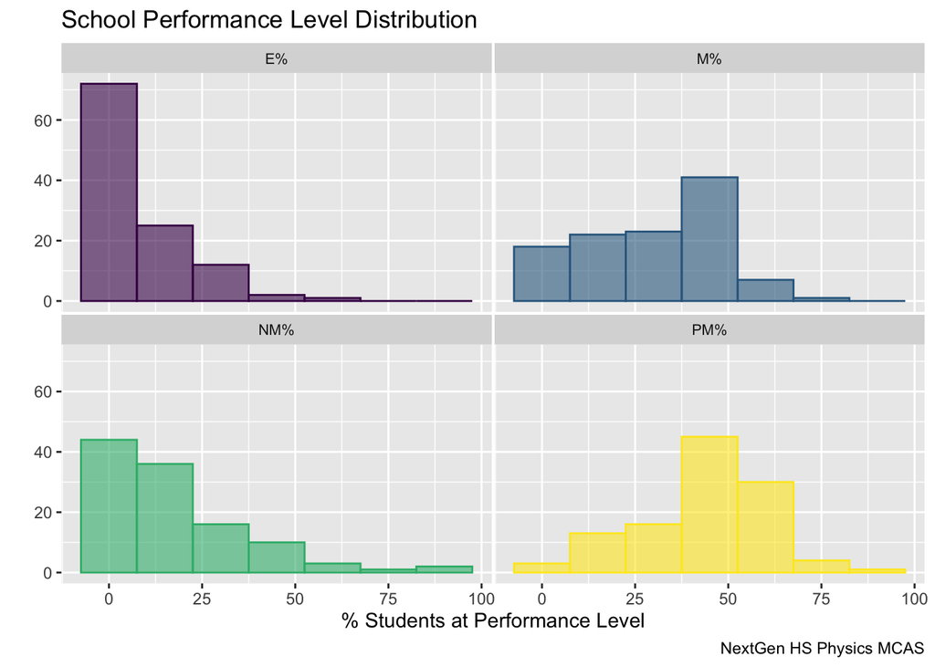

```r
HSPhy_NextGen_SchoolSum%>%
  select(`E%`, `M%`, `PM%`, `NM%`)%>%
  pivot_longer(c(1:4), names_to = "Performance Level", values_to = "% Students")%>%
   ggplot( aes(x=`% Students`, color=`Performance Level`, fill=`Performance Level`)) +
    geom_histogram(alpha=0.6, binwidth = 15) +
    scale_fill_viridis(discrete=TRUE) +
    scale_color_viridis(discrete=TRUE) +
    #theme_ipsum() +
    theme(
      legend.position="none",
      panel.spacing = unit(0.1, "lines"),
      strip.text.x = element_text(size = 8)
    ) +

    facet_wrap(~`Performance Level`)+
      labs( y = "",
            title = "School Performance Level Distribution",
            x = "% Students at Performance Level",
            caption = "NextGen HS Physics MCAS")
```

## Distribution of School Performance and Variability by Practice Cat

Although `Mathematics and Data` and `Evidence, Reasoning, and Modeling` items have strong and equal weighting in the HS Introductory Physics exam, student performance distributions are noticeably different across these practice categories.

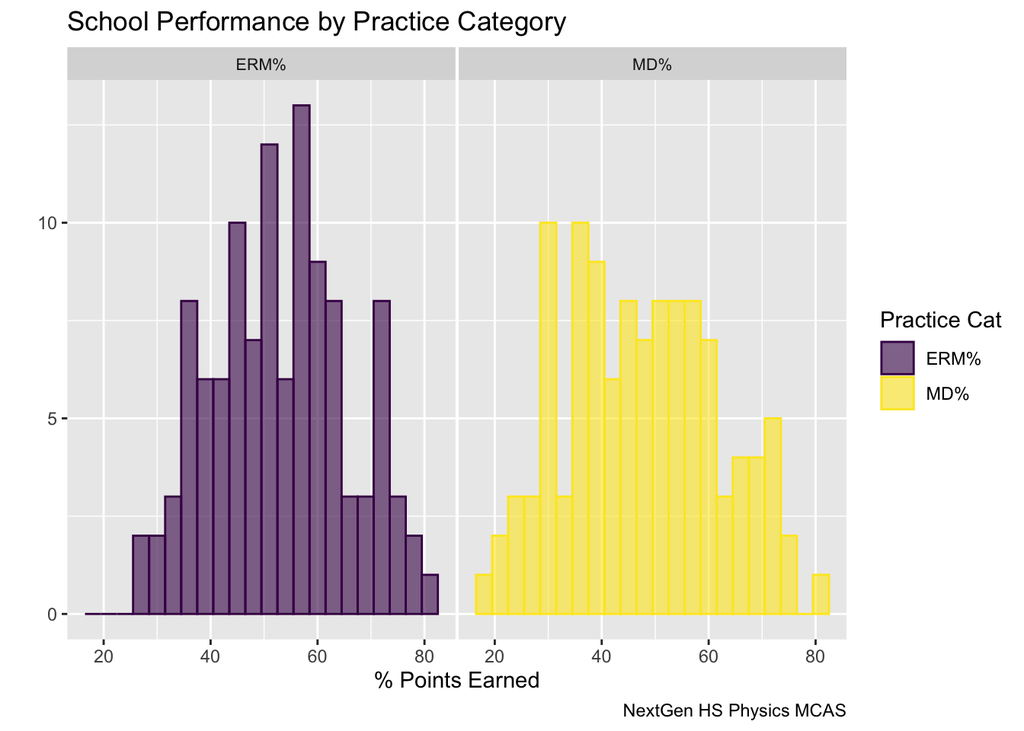

```r
HSPhy_NextGen_SchoolSum%>%
  select(`ERM%`, `MD%`)%>%
  pivot_longer(c(1:2), names_to = "Practice Cat", values_to = "% Points")%>%
   ggplot( aes(x=`% Points`, color=`Practice Cat`, fill=`Practice Cat`)) +
    geom_histogram(alpha=0.6, binwidth = 3) +
    scale_fill_viridis(discrete=TRUE) +
    scale_color_viridis(discrete=TRUE) +
    #theme_ipsum() +
    theme(
      panel.spacing = unit(0.1, "lines"),
      strip.text.x = element_text(size = 8)
    ) +

    facet_wrap(~`Practice Cat`)+
      labs( y = "",
            title = "School Performance by Practice Category",
            x = "% Points Earned",
            caption = "NextGen HS Physics MCAS")
```

```r
  #ggtitle("Practice Category Performance")
```

When considering the variability of a school’s performance on items relative to the state by `Practice Category`, `SD MD Diff`, and `SD ERM Diff`, we can see that `Mathematics and Data` is skewed more to the right.

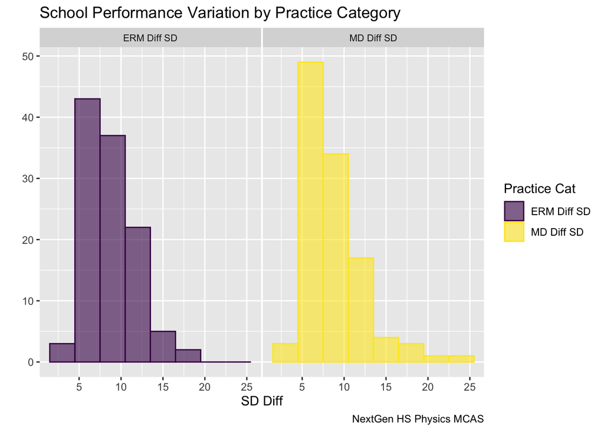

```r
  HSPhy_NextGen_SchoolSum%>%
  select(`ERM Diff SD`, `MD Diff SD`)%>%
  pivot_longer(c(1:2), names_to = "Practice Cat", values_to = "SD Diff")%>%
   ggplot( aes(x=`SD Diff`, color=`Practice Cat`, fill=`Practice Cat`)) +
    geom_histogram(alpha=0.6, binwidth = 3) +
    scale_fill_viridis(discrete=TRUE) +
    scale_color_viridis(discrete=TRUE) +
   # theme_ipsum() +
    theme(
      panel.spacing = unit(0.1, "lines"),
      strip.text.x = element_text(size = 8)
    ) +
      labs( y = "",
            title = "School Performance Variation by Practice Category",
            x = "SD Diff",
            caption = "NextGen HS Physics MCAS") +
    facet_wrap(~`Practice Cat`)
```

## Mathematics and Data vs. Evidence Reasoning and Modeling (Practice Category)

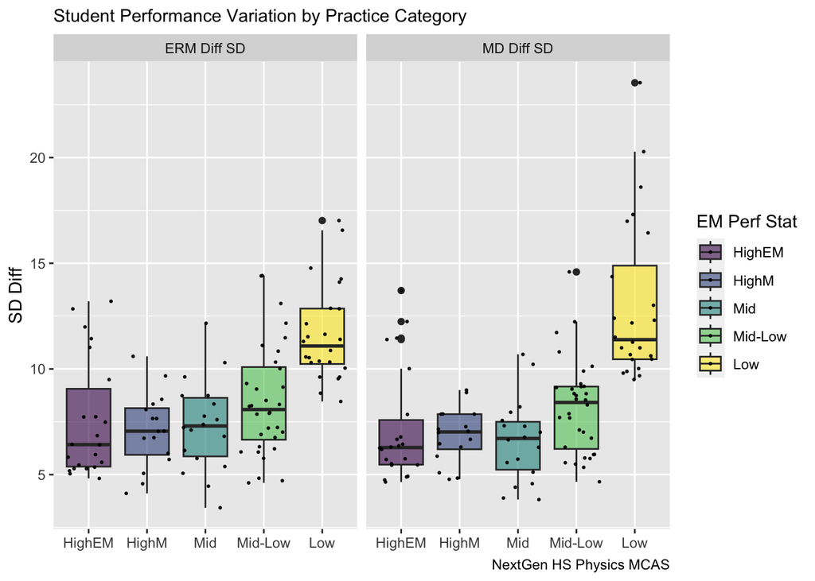

```r
HSPhy_NextGen_SchoolSum%>%
  select(`EM Perf Stat`, `ERM Diff SD`, `MD Diff SD` )%>%
  pivot_longer(c(2:3), names_to = "Practice Cat", values_to = "SD Diff")%>%
  ggplot( aes(x= `EM Perf Stat`, y=`SD Diff`, fill= `EM Perf Stat`)) +
    geom_boxplot() +
    scale_fill_viridis(discrete = TRUE, alpha=0.6) +
    geom_jitter(color="black", size=0.4, alpha=0.9) +

    theme(
      plot.title = element_text(size=11),
      axis.title.x=element_blank(),
      #axis.text.x=element_blank()
    ) +

    labs( y = "SD Diff",
            title = "Student Performance Variation by Practice Category",
            x = "",
            caption = "NextGen HS Physics MCAS") +
  facet_wrap(~`Practice Cat`)
```

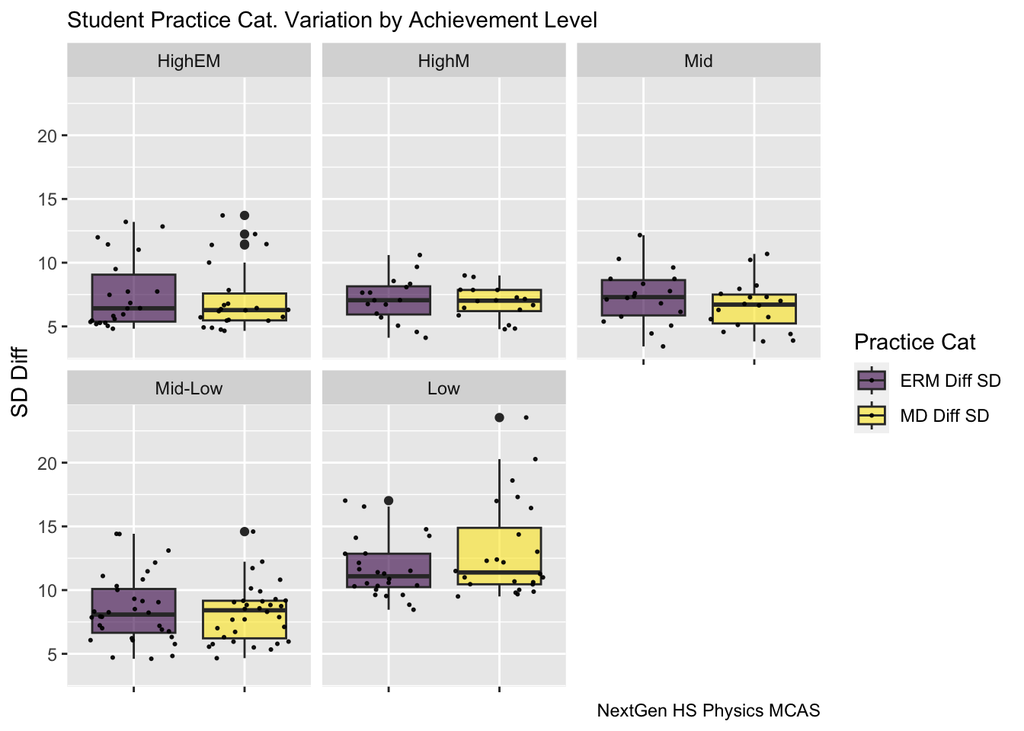

```r
HSPhy_NextGen_SchoolSum%>%
  select(`EM Perf Stat`, `ERM Diff SD`, `MD Diff SD` )%>%
  pivot_longer(c(2:3), names_to = "Practice Cat", values_to = "SD Diff")%>%
  ggplot( aes(x= `Practice Cat`, y=`SD Diff`, fill= `Practice Cat`)) +
    geom_boxplot() +
    scale_fill_viridis(discrete = TRUE, alpha=0.6) +
    geom_jitter(color="black", size=0.4, alpha=0.9) +
    #theme_ipsum() +
    theme(

      plot.title = element_text(size=11),
      axis.title.x=element_blank(),
      axis.text.x=element_blank()
    ) +
     labs( y = "SD Diff",
            title = "Student Practice Cat. Variation by Achievement Level",
            x = "",
            caption = "NextGen HS Physics MCAS") +
    #xlab("")+
  facet_wrap(~`EM Perf Stat`)
```

These images, seem to suggest that students at all schools seem to have more difficulty with `Mathematics and Data` items as compared to `Evidence, Reasoning, and Modeling Items`.

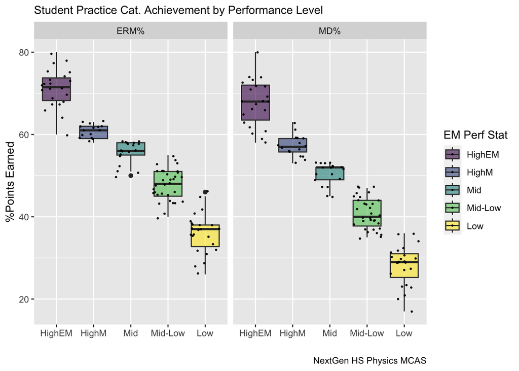

```r
HSPhy_NextGen_SchoolSum%>%
  select(`EM Perf Stat`, `ERM%`, `MD%` )%>%
  pivot_longer(c(2:3), names_to = "Practice Cat", values_to = "%Points")%>%
  ggplot( aes(x= `EM Perf Stat`, y=`%Points`, fill= `EM Perf Stat`)) +
    geom_boxplot() +
    scale_fill_viridis(discrete = TRUE, alpha=0.6) +
    geom_jitter(color="black", size=0.4, alpha=0.9) +
    #theme_ipsum() +
    theme(

      plot.title = element_text(size=11)
    ) +
    labs( y = "%Points Earned",
            title = "Student Practice Cat. Achievement by Performance Level",
            x = "",
            caption = "NextGen HS Physics MCAS") +
    #xlab("")+
  facet_wrap(~`Practice Cat`)
```

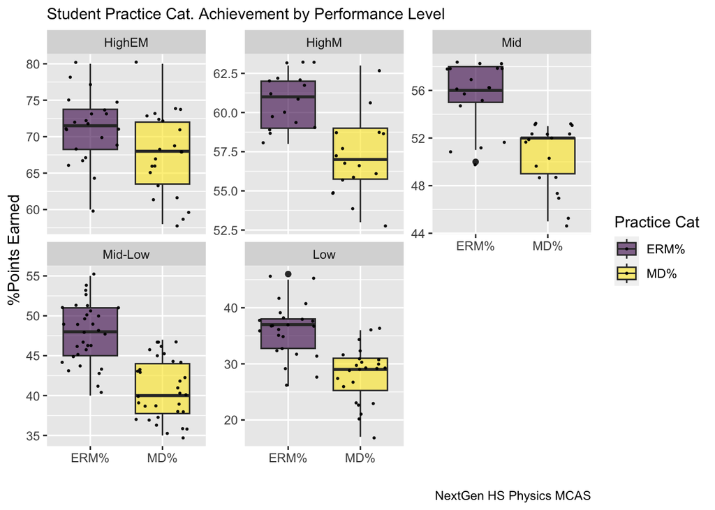

```r
HSPhy_NextGen_SchoolSum%>%
  select(`EM Perf Stat`, `ERM%`, `MD%` )%>%
  pivot_longer(c(2:3), names_to = "Practice Cat", values_to = "%Points")%>%
  ggplot( aes(x= `Practice Cat`, y=`%Points`, fill= `Practice Cat`)) +
    geom_boxplot() +
    scale_fill_viridis(discrete = TRUE, alpha=0.6) +
    geom_jitter(color="black", size=0.4, alpha=0.9) +
    #theme_ipsum() +
    theme(

      plot.title = element_text(size=11)
    ) +
    labs( y = "%Points Earned",
            title = "Student Practice Cat. Achievement by Performance Level",
            x = "",
            caption = "NextGen HS Physics MCAS") +
    #xlab("")+
  facet_wrap(~`EM Perf Stat`, scale ="free_y")
```

```r
# HSPhy_NextGen_SchoolSum%>%
#   select(`EM Perf Stat`, `ERMDiff`, `MDDiff` )%>%
#   pivot_longer(c(2:3), names_to = "Practice Cat", values_to = "%Points")%>%
#   ggplot( aes(x= `EM Perf Stat`, y=`%Points`, fill= `EM Perf Stat`)) +
#     geom_boxplot() +
#     scale_fill_viridis(discrete = TRUE, alpha=0.6) +
#     geom_jitter(color="black", size=0.4, alpha=0.9) +
#     #theme_ipsum() +
#     theme(
#
#       plot.title = element_text(size=11)
#     ) +
#     labs( y = "%Points Earned",
#             title = "Student Practice Cat. Achievement by Performance Level",
#             x = "",
#             caption = "NextGen HS Physics MCAS") +
#     #xlab("")+
#   facet_wrap(~`Practice Cat`)

# HSPhy_NextGen_SchoolSum%>%
#   select(`EM Perf Stat`, `ERM%`, `MD%` )%>%
#   pivot_longer(c(2:3), names_to = "Practice Cat", values_to = "%Points")%>%
#   ggplot( aes(x= `Practice Cat`, y=`%Points`, fill= `Practice Cat`)) +
#     geom_boxplot() +
#     scale_fill_viridis(discrete = TRUE, alpha=0.6) +
#     geom_jitter(color="black", size=0.4, alpha=0.9) +
#     #theme_ipsum() +
#     theme(
#
#       plot.title = element_text(size=11)
#     ) +
#     labs( y = "%Points Earned",
#             title = "Student Practice Cat. Achievement by Performance Level",
#             x = "",
#             caption = "NextGen HS Physics MCAS") +
#     #xlab("")+
#   facet_wrap(~`EM Perf Stat`, scale ="free_y")


# HSPhy_NextGen_SchoolSum %>%
#   ggplot( aes(x= `EM Perf Stat`, y=`MD%`, fill= `EM Perf Stat`)) +
#     geom_boxplot() +
#     scale_fill_viridis(discrete = TRUE, alpha=0.6) +
#     geom_jitter(color="black", size=0.4, alpha=0.9) +
#     theme_ipsum() +
#     theme(
#       legend.position="none",
#       plot.title = element_text(size=11)
#     ) +
#     ggtitle("A boxplot with jitter") +
#     xlab("")

# HSPhy_NextGen_SchoolSum %>%
#   ggplot( aes(x= `EM Perf Stat`, y=`MD Diff SD`, fill= `EM Perf Stat`)) +
#     geom_boxplot() +
#     scale_fill_viridis(discrete = TRUE, alpha=0.6) +
#     geom_jitter(color="black", size=0.4, alpha=0.9) +
#     theme_ipsum() +
#     theme(
#       legend.position="none",
#       plot.title = element_text(size=11)
#     ) +
#     ggtitle("A boxplot with jitter") +
#     xlab("")
#
# HSPhy_NextGen_SchoolSum %>%
#   ggplot( aes(x= `EM Perf Stat`, y=`ERM Diff SD`, fill= `EM Perf Stat`)) +
#     geom_boxplot() +
#     scale_fill_viridis(discrete = TRUE, alpha=0.6) +
#     geom_jitter(color="black", size=0.4, alpha=0.9) +
#     theme_ipsum() +
#     theme(
#       legend.position="none",
#       plot.title = element_text(size=11)
#     ) +
#     ggtitle("A boxplot with jitter") +
#     xlab("")
#
# HSPhy_NextGen_SchoolSum %>%
#   ggplot( aes(x= `EM Perf Stat`, y=`ERM%`, fill= `EM Perf Stat`)) +
#     geom_boxplot() +
#     scale_fill_viridis(discrete = TRUE, alpha=0.6) +
#     geom_jitter(color="black", size=0.4, alpha=0.9) +
#     theme_ipsum() +
#     theme(
#       legend.position="none",
#       plot.title = element_text(size=11)
#     ) +
#     ggtitle("A boxplot with jitter") +
#     xlab("")
```

## Distribution of School Performance and Variability by Reporting Cat

Here we can visualize the variability of a school’s performance on items partitioned by Content `Reporting Category` of `Motion and Forces`, `Energy`, and `Waves` via: `MF%`/`SD MF Diff`, `EN%`/`SD EN Diff`, and `WA%`/`SD WA Diff`.

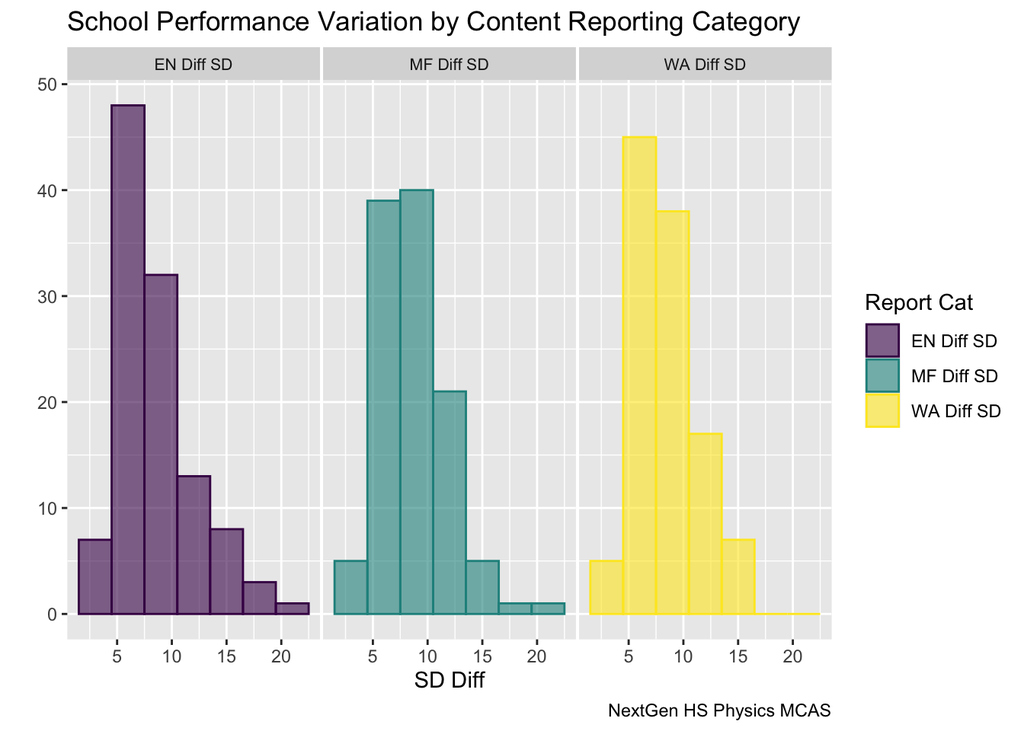

```r
  HSPhy_NextGen_SchoolSum%>%
  select(`EM Perf Stat`, `MF Diff SD`, `EN Diff SD`, `WA Diff SD` )%>%
  pivot_longer(c(2:4), names_to = "Report Cat", values_to = "SD Diff")%>%
  ggplot( aes(x=`SD Diff`, color=`Report Cat`, fill=`Report Cat`)) +
    geom_histogram(alpha=0.6, binwidth = 3) +
    scale_fill_viridis(discrete=TRUE) +
    scale_color_viridis(discrete=TRUE) +
    #theme_ipsum() +
    theme(
      panel.spacing = unit(0.1, "lines"),
      strip.text.x = element_text(size = 8)
    ) +
      labs( y = "",
            title = "School Performance Variation by Content Reporting Category",
            x = "SD Diff",
            caption = "NextGen HS Physics MCAS") +
  facet_wrap(~`Report Cat`)
```

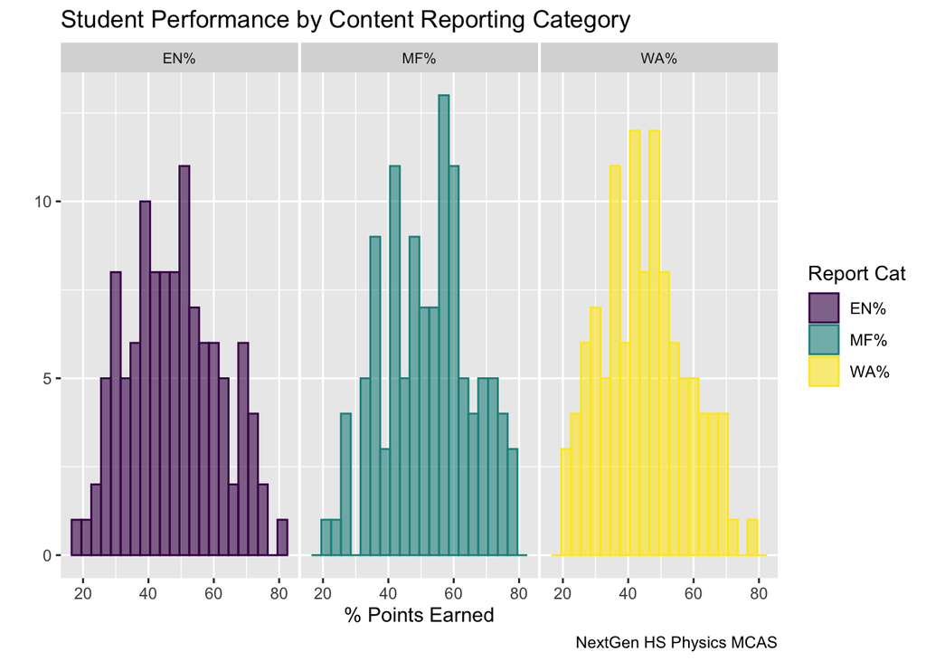

```r
HSPhy_NextGen_SchoolSum%>%
  select(`EM Perf Stat`, `MF%`, `EN%`, `WA%` )%>%
  pivot_longer(c(2:4), names_to = "Report Cat", values_to = "% Points")%>%
 ggplot( aes(x=`% Points`, color=`Report Cat`, fill=`Report Cat`)) +
    geom_histogram(alpha=0.6, binwidth = 3) +
    scale_fill_viridis(discrete=TRUE) +
    scale_color_viridis(discrete=TRUE) +
    #theme_ipsum() +
    theme(
      panel.spacing = unit(0.1, "lines"),
      strip.text.x = element_text(size = 8)
    ) +

    facet_wrap(~`Report Cat`)+
      labs( y = "",
            title = "Student Performance by Content Reporting Category",
            x = "% Points Earned",
            caption = "NextGen HS Physics MCAS")
```

```r
  #ggtitle("Practice Category Performance")
```

## Motion and Forces vs. Energy vs. Waves (Reporting Category)

These images suggest that most schools exhibit similar levels of variability in performance relative to the state across all reporting categories. Schools with the *lowest percentage* of students `Exceeding` expectations exhibit *high variability* in performance across all content reporting categories, but seem to have lower variability on `Waves` items.

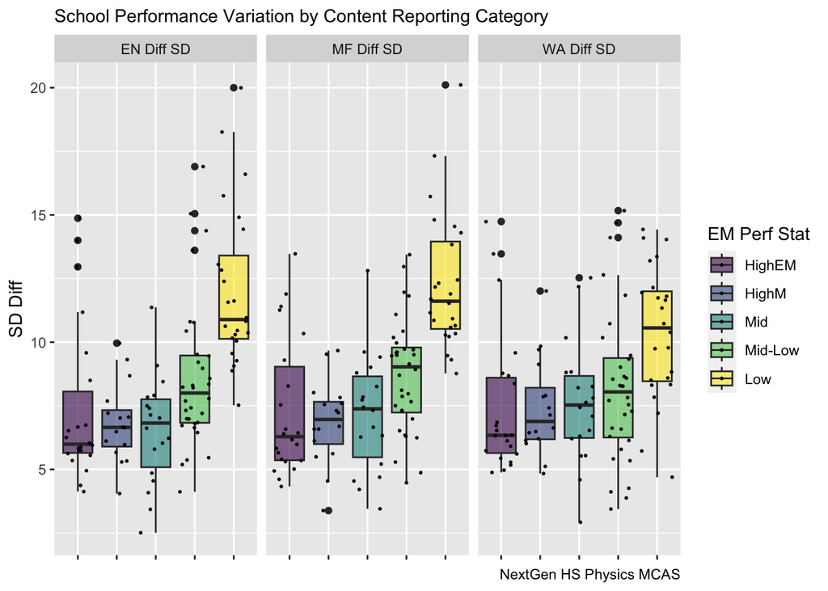

```r
HSPhy_NextGen_SchoolSum%>%
  select(`EM Perf Stat`, `MF Diff SD`, `EN Diff SD`, `WA Diff SD` )%>%
  pivot_longer(c(2:4), names_to = "Report Cat", values_to = "SD Diff")%>%
  ggplot( aes(x= `EM Perf Stat`, y=`SD Diff`, fill= `EM Perf Stat`)) +
    geom_boxplot() +
    scale_fill_viridis(discrete = TRUE, alpha=0.6) +
    geom_jitter(color="black", size=0.4, alpha=0.9) +

    theme(
      plot.title = element_text(size=11),
      axis.title.x=element_blank(),
      axis.text.x=element_blank()
    ) +

    labs( y = "SD Diff",
            title = "School Performance Variation by Content Reporting Category",
            x = "",
            caption = "NextGen HS Physics MCAS") +
  facet_wrap(~`Report Cat`)
```

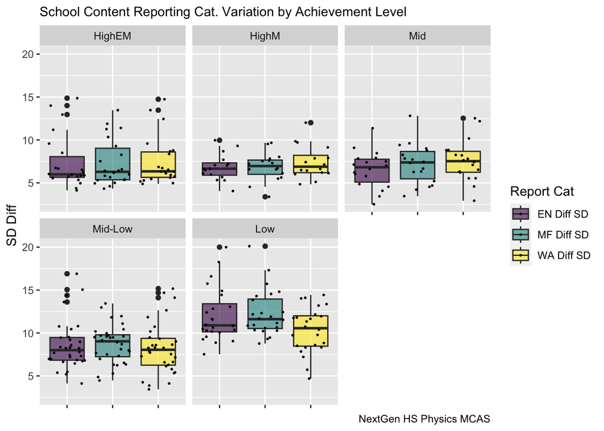

```r
HSPhy_NextGen_SchoolSum%>%
  select(`EM Perf Stat`, `MF Diff SD`, `EN Diff SD`, `WA Diff SD` )%>%
  pivot_longer(c(2:4), names_to = "Report Cat", values_to = "SD Diff")%>%
  ggplot( aes(x= `Report Cat`, y=`SD Diff`, fill= `Report Cat`)) +
    geom_boxplot() +
    scale_fill_viridis(discrete = TRUE, alpha=0.6) +
    geom_jitter(color="black", size=0.4, alpha=0.9) +
    #theme_ipsum() +
    theme(

      plot.title = element_text(size=11),
      axis.title.x=element_blank(),
      axis.text.x=element_blank()
    ) +
     labs( y = "SD Diff",
            title = "School Content Reporting Cat. Variation by Achievement Level",
            x = "",
            caption = "NextGen HS Physics MCAS") +
    #xlab("")+
  facet_wrap(~`EM Perf Stat`)
```

```r
# HSPhy_NextGen_SchoolSum%>%
#   select(`EM Perf Stat`, `MF%`, `EN%`, `WA%` )%>%
#   pivot_longer(c(2:4), names_to = "Report Cat", values_to = "% Points")%>%
#   ggplot( aes(x= `Report Cat`, y=`% Points`, fill= `Report Cat`)) +
#     geom_boxplot() +
#     scale_fill_viridis(discrete = TRUE, alpha=0.6) +
#     geom_jitter(color="black", size=0.4, alpha=0.9) +
#     #theme_ipsum() +
#     theme(
#
#       plot.title = element_text(size=11),
#       axis.title.x=element_blank(),
#       axis.text.x=element_blank()
#     ) +
#      labs( y = "SD Diff",
#             title = "School Content Reporting Cat. Performance by Achievement Level",
#             x = "",
#             caption = "NextGen HS Physics MCAS") +
#     #xlab("")+
#   facet_wrap(~`EM Perf Stat`)

# HSPhy_NextGen_SchoolSum %>%
#   ggplot( aes(x= `EM Perf Stat`, y=`MF%`, fill= `EM Perf Stat`)) +
#     geom_boxplot() +
#     scale_fill_viridis(discrete = TRUE, alpha=0.6) +
#     geom_jitter(color="black", size=0.4, alpha=0.9) +
#     theme_ipsum() +
#     theme(
#       legend.position="none",
#       plot.title = element_text(size=11)
#     ) +
#     ggtitle("A boxplot with jitter") +
#     xlab("")
#
# HSPhy_NextGen_SchoolSum %>%
#   ggplot( aes(x= `EM Perf Stat`, y=`MF Diff SD`, fill= `EM Perf Stat`)) +
#     geom_boxplot() +
#     scale_fill_viridis(discrete = TRUE, alpha=0.6) +
#     geom_jitter(color="black", size=0.4, alpha=0.9) +
#     theme_ipsum() +
#     theme(
#       legend.position="none",
#       plot.title = element_text(size=11)
#     ) +
#     ggtitle("A boxplot with jitter") +
#     xlab("")
#
#
#
# HSPhy_NextGen_SchoolSum %>%
#   ggplot( aes(x= `EM Perf Stat`, y=`EN%`, fill= `EM Perf Stat`)) +
#     geom_boxplot() +
#     scale_fill_viridis(discrete = TRUE, alpha=0.6) +
#     geom_jitter(color="black", size=0.4, alpha=0.9) +
#     theme_ipsum() +
#     theme(
#       legend.position="none",
#       plot.title = element_text(size=11)
#     ) +
#     ggtitle("A boxplot with jitter") +
#     xlab("")
#
# HSPhy_NextGen_SchoolSum %>%
#   ggplot( aes(x= `EM Perf Stat`, y=`EN Diff SD`, fill= `EM Perf Stat`)) +
#     geom_boxplot() +
#     scale_fill_viridis(discrete = TRUE, alpha=0.6) +
#     geom_jitter(color="black", size=0.4, alpha=0.9) +
#     theme_ipsum() +
#     theme(
#       legend.position="none",
#       plot.title = element_text(size=11)
#     ) +
#     ggtitle("A boxplot with jitter") +
#     xlab("")
#
# HSPhy_NextGen_SchoolSum %>%
#   ggplot( aes(x= `EM Perf Stat`, y=`WA%`, fill= `EM Perf Stat`)) +
#     geom_boxplot() +
#     scale_fill_viridis(discrete = TRUE, alpha=0.6) +
#     geom_jitter(color="black", size=0.4, alpha=0.9) +
#     theme_ipsum() +
#     theme(
#       legend.position="none",
#       plot.title = element_text(size=11)
#     ) +
#     ggtitle("A boxplot with jitter") +
#     xlab("")
#
# HSPhy_NextGen_SchoolSum %>%
#   ggplot( aes(x= `EM Perf Stat`, y=`WA Diff SD`, fill= `EM Perf Stat`)) +
#     geom_boxplot() +
#     scale_fill_viridis(discrete = TRUE, alpha=0.6) +
#     geom_jitter(color="black", size=0.4, alpha=0.9) +
#     theme_ipsum() +
#     theme(
#       legend.position="none",
#       plot.title = element_text(size=11)
#     ) +
#     ggtitle("A boxplot with jitter") +
#     xlab("")
```

# Hypothesis Testing

```r
HSPhy_NextGen_SchoolSum
```

| Subject | School Name | School Code | EN% | MF% | WA% | EN Diff SD | MF Diff SD | WA Diff SD | IQ% | MD% | ERM% | None% | IQ Diff SD | MD Diff SD | ERM Diff SD | None Diff SD | Tested Students | E% | M% | PM% | NM% | E%State | M%State | PM%State | NM%State | EDiff | MDiff | PMDiff | NMDiff | … |
| --- | --- | --- | --- | --- | --- | --- | --- | --- | --- | --- | --- | --- | --- | --- | --- | --- | --- | --- | --- | --- | --- | --- | --- | --- | --- | --- | --- | --- | --- | --- |
| PHY | Agawam High | 00050505 | 47 | 52 | 46 | 5.46 | 6.24 | 3.88 | 54 | 47 | 53 | 45 | 7.02 | 5.56 | 4.61 | 8.03 | 424 | 2 | 32 | 59 | 7 | 14 | 36 | 38 | 12 | -12 | -4 | 21 | -5 | … |
| PHY | Andover High | 00090505 | 63 | 67 | 61 | 4.13 | 5.31 | 4.97 | 63 | 63 | 67 | 63 | 3.06 | 4.65 | 5.35 | 4.46 | 785 | 25 | 43 | 28 | 4 | 14 | 36 | 38 | 12 | 11 | 7 | -10 | -8 | … |
| PHY | Arlington High | 00100505 | 67 | 72 | 61 | 4.95 | 4.33 | 5.91 | 69 | 66 | 72 | 65 | 5.51 | 4.92 | 5.04 | 5.29 | 727 | 28 | 48 | 23 | 2 | 14 | 36 | 38 | 12 | 14 | 12 | -15 | -10 | … |
| PHY | Attleboro High | 00160505 | 49 | 56 | 47 | 3.43 | 3.45 | 6.53 | 53 | 50 | 55 | 48 | 4.04 | 3.82 | 4.45 | 5.99 | 920 | 7 | 36 | 48 | 10 | 14 | 36 | 38 | 12 | -7 | 0 | 10 | -2 | … |
| PHY | Barnstable High | 00200505 | 42 | 48 | 43 | 13.61 | 10.43 | 15.17 | 37 | 41 | 51 | 49 | 13.20 | 10.81 | 11.11 | 16.43 | 44 | 2 | 25 | 59 | 14 | 14 | 36 | 38 | 12 | -12 | -11 | 21 | 2 | … |
| PHY | Bedford High | 00230505 | 69 | 71 | 62 | 5.74 | 5.35 | 6.53 | 70 | 67 | 72 | 64 | 6.03 | 6.30 | 5.82 | 4.02 | 433 | 31 | 41 | 25 | 2 | 14 | 36 | 38 | 12 | 17 | 5 | -13 | -10 | … |
| PHY | Belmont High | 00260505 | 75 | 78 | 72 | 6.74 | 6.40 | 5.74 | 74 | 74 | 78 | 76 | 9.07 | 6.44 | 6.41 | 5.56 | 700 | 49 | 35 | 13 | 2 | 14 | 36 | 38 | 12 | 35 | -1 | -25 | -10 | … |
| PHY | Henderson K-12 Inclusion School Upper | 00350426 | 36 | 39 | 33 | 9.56 | 9.31 | 5.72 | 30 | 34 | 41 | 34 | 4.04 | 9.50 | 8.85 | 5.70 | 110 | 1 | 12 | 52 | 35 | 14 | 36 | 38 | 12 | -13 | -24 | 14 | 23 | … |
| PHY | Brighton High School | 00350505 | 30 | 35 | 34 | 8.88 | 10.86 | 9.74 | 26 | 31 | 36 | 33 | 3.06 | 10.45 | 10.57 | 9.63 | 119 | 0 | 13 | 38 | 50 | 14 | 36 | 38 | 12 | -14 | -23 | 0 | 38 | … |
| PHY | Boston International High School & Newcomers Academy | 00350507 | 23 | 27 | 26 | 11.62 | 12.32 | 13.20 | 17 | 23 | 29 | 24 | 9.00 | 12.30 | 12.85 | 11.61 | 118 | 0 | 0 | 35 | 65 | 14 | 36 | 38 | 12 | -14 | -36 | -3 | 53 | … |

[output cut: 102 more lines]

```r
fit_md = lm(`E%` ~ log(`MD Diff SD`), data = HSPhy_NextGen_SchoolSum)
summary(fit_md)
```

```
Call:
lm(formula = `E%` ~ log(`MD Diff SD`), data = HSPhy_NextGen_SchoolSum)

Residuals:
    Min      1Q  Median      3Q     Max
-12.014  -6.176  -3.768   1.090  53.978

Coefficients:
                  Estimate Std. Error t value Pr(>|t|)
(Intercept)         32.917      6.116   5.382 4.21e-07 ***
log(`MD Diff SD`)  -11.675      2.895  -4.033 0.000102 ***
---
Signif. codes:  0 '***' 0.001 '**' 0.01 '*' 0.05 '.' 0.1 ' ' 1

Residual standard error: 11.25 on 110 degrees of freedom
Multiple R-squared:  0.1288,    Adjusted R-squared:  0.1209
F-statistic: 16.26 on 1 and 110 DF,  p-value: 0.0001019
```

```r
fit_erm = lm(`E%` ~ `ERM Diff SD`, data = HSPhy_NextGen_SchoolSum)
#summary(fit_erm)

fit_erm_md = lm(`E%` ~ log(`MD Diff SD`) + log(`ERM Diff SD`) + log(`MD Diff SD`)*log(`ERM Diff SD`), data = HSPhy_NextGen_SchoolSum)
#summary(fit_erm_md)


fit_md_percent = lm(`E%` ~ log(`MD%`) + log(`ERM%`) + log(`MD%`)*log(`ERM%`), data = HSPhy_NextGen_SchoolSum)

#summary(fit_md_percent)

HSPhy_NextGen_SchoolSum%>%
  select(`MD%`, `E%`)
```

| MD% | E% |
| --- | --- |
| 47 | 2 |
| 63 | 25 |
| 66 | 28 |
| 50 | 7 |
| 41 | 2 |
| 67 | 31 |
| 74 | 49 |
| 34 | 1 |
| 31 | 0 |
| 23 | 0 |

[output cut: 102 more lines]

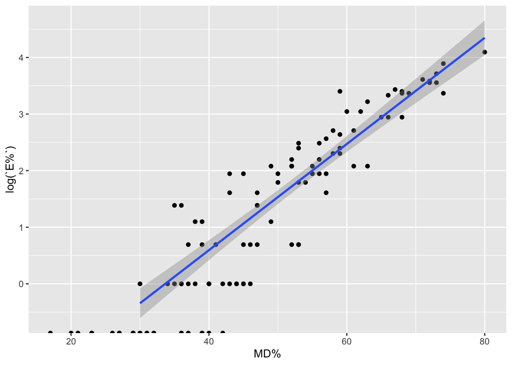

```r
ggplot(data = HSPhy_NextGen_SchoolSum, aes(x = `MD%`, y = log(`E%`))) +
  geom_point() +
  geom_smooth(method="lm", se=T)
```

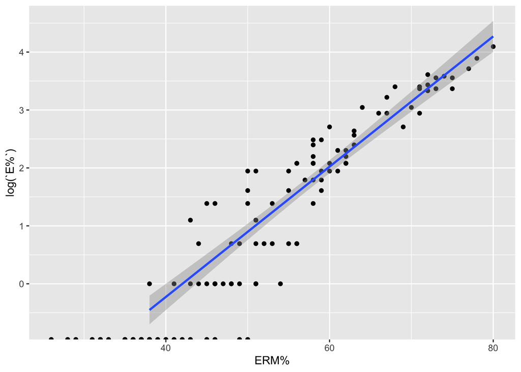

```r
ggplot(data = HSPhy_NextGen_SchoolSum, aes(x = `ERM%`, y = log(`E%`))) +
  geom_point() +
  geom_smooth(method="lm", se=T)
```

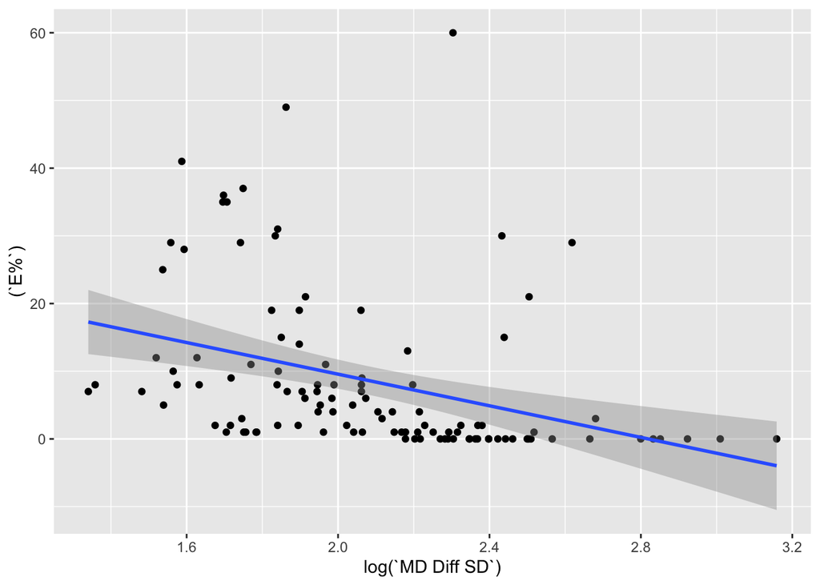

```r
ggplot(data = HSPhy_NextGen_SchoolSum, aes(x = log(`MD Diff SD`), y = (`E%`))) +
  geom_point() +
  geom_smooth(method="lm", se=T)
```

```r
#HSPhy_NextGen_SchoolSum.isna()

fit_wa = lm((`E%`) ~ log(`WA%`), data = HSPhy_NextGen_SchoolSum)
summary(fit_wa)
```

```
Call:
lm(formula = (`E%`) ~ log(`WA%`), data = HSPhy_NextGen_SchoolSum)

Residuals:
    Min      1Q  Median      3Q     Max
-10.575  -5.428  -2.218   4.028  33.155

Coefficients:
            Estimate Std. Error t value Pr(>|t|)
(Intercept) -104.236      9.087  -11.47   <2e-16 ***
log(`WA%`)    29.999      2.408   12.46   <2e-16 ***
---
Signif. codes:  0 '***' 0.001 '**' 0.01 '*' 0.05 '.' 0.1 ' ' 1

Residual standard error: 7.761 on 110 degrees of freedom
Multiple R-squared:  0.5853,    Adjusted R-squared:  0.5816
F-statistic: 155.3 on 1 and 110 DF,  p-value: < 2.2e-16
```

```r
fit_md = lm((`E%`) ~ log(`MD%`), data = HSPhy_NextGen_SchoolSum)
summary(fit_md)
```

```
Call:
lm(formula = (`E%`) ~ log(`MD%`), data = HSPhy_NextGen_SchoolSum)

Residuals:
    Min      1Q  Median      3Q     Max
-11.069  -5.617  -1.981   3.093  35.895

Coefficients:
            Estimate Std. Error t value Pr(>|t|)
(Intercept)  -93.347      8.951  -10.43   <2e-16 ***
log(`MD%`)    26.803      2.344   11.43   <2e-16 ***
---
Signif. codes:  0 '***' 0.001 '**' 0.01 '*' 0.05 '.' 0.1 ' ' 1

Residual standard error: 8.147 on 110 degrees of freedom
Multiple R-squared:  0.5431,    Adjusted R-squared:  0.5389
F-statistic: 130.7 on 1 and 110 DF,  p-value: < 2.2e-16
```

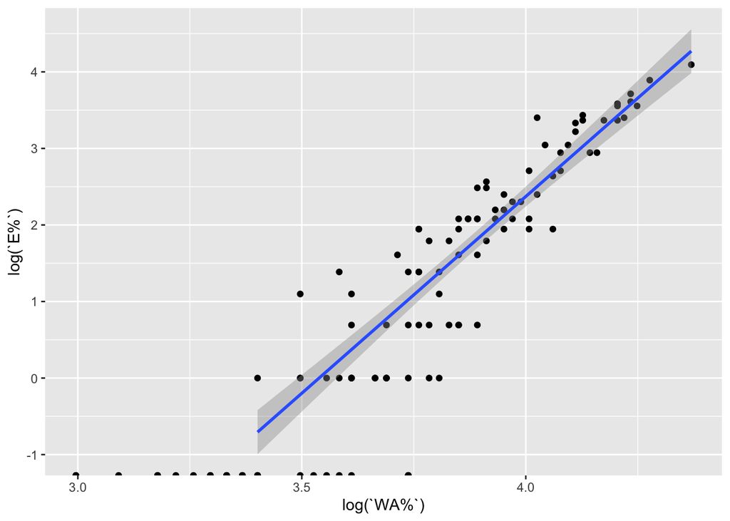

```r
#fit_erm = lm(`E%` ~ `ERM Diff SD`, data = HSPhy_NextGen_SchoolSum)
#summary(fit_erm)

#fit_erm_md = lm(`E%` ~ log(`MD Diff SD`) + log(`ERM Diff SD`) + log(`MD Diff SD`)*log(`ERM Diff SD`), data = HSPhy_NextGen_SchoolSum)
#summary(fit_erm_md)


#fit_md_percent = lm(`E%` ~ log(`MD%`) + log(`ERM%`) + log(`MD%`)*log(`ERM%`), data = HSPhy_NextGen_SchoolSum)

#summary(fit_md_percent)

#HSPhy_NextGen_SchoolSum%>%
#  select(`MD%`, `E%`)

ggplot(data = HSPhy_NextGen_SchoolSum, aes(x = log(`WA%`), y = log(`E%`))) +
  geom_point() +
  geom_smooth(method="lm", se=T)
```

```r
#ggplot(data = HSPhy_NextGen_SchoolSum, aes(x = `ERM%`, y = log(`E%`))) +
 # geom_point() +
#  geom_smooth(method="lm", se=T)

#ggplot(data = HSPhy_NextGen_SchoolSum, aes(x = log(`MD Diff SD`), y = (`E%`))) +
 # geom_point() +
#  geom_smooth(method="lm", se=T)
```

## References

Chief State School Officers, Council of. 2021. “How States Can Support the Adoption & Effective Use of High Quality Standards-Aligned Instructional Materials.” https://753a0706.flowpaper.com/CCSSOIMPDCaseStudyOVERVIEWFINAL/#page=1.

Chingos, & Whitehurst, M. M. 2012. “Choosing Blindly. Instructional Materials, Teacher Effectiveness, and the Common Core.” https://www.brookings.edu/wp-content/uploads/2016/06/0410_curriculum_chingos_whitehurst.pdf.

DESE. 2022. “HighSchool Introductory Physics Item Report.” https://profiles.doe.mass.edu/mcas/mcasitems2.aspx?grade=HS&subjectcode=PHY&linkid=23&orgcode=04830000&fycode=2022&orgtypecode=5&.

Greer, W. 2018. “The 50 Year History of the Common Core.” *The Journal of Educational Foundations* 31 (3&4): 100–117. https://files.eric.ed.gov/fulltext/EJ1212104.pdf.

Papy, Mantil, J. P. 2020. “Lifting All Boats? Accomplishments and Challenges from 20 Years of Education Reform in Massachusetts.” https://annenberg.brown.edu/sites/default/files/LiftingAllBoats_FINAL.pdf.